# Part A

# PART B

# Read the data set, clean the data and prepare final dataset to be used for analysis.

```python
basketBallDf = pd.read_csv("Basketball.csv")
basketBallDf.head()
```

|  | Team | Tournament | Score | PlayedGames | WonGames | DrawnGames | LostGames | BasketScored | BasketGiven | TournamentChampion | Runner-up | TeamLaunch | HighestPositionHeld |
| --- | --- | --- | --- | --- | --- | --- | --- | --- | --- | --- | --- | --- | --- |
| 0 | Team 1 | 86 | 4385 | 2762 | 1647 | 552 | 563 | 5947 | 3140 | 33 | 23 | 1929 | 1 |
| 1 | Team 2 | 86 | 4262 | 2762 | 1581 | 573 | 608 | 5900 | 3114 | 25 | 25 | 1929 | 1 |
| 2 | Team 3 | 80 | 3442 | 2614 | 1241 | 598 | 775 | 4534 | 3309 | 10 | 8 | 1929 | 1 |
| 3 | Team 4 | 82 | 3386 | 2664 | 1187 | 616 | 861 | 4398 | 3469 | 6 | 6 | 1931to32 | 1 |
| 4 | Team 5 | 86 | 3368 | 2762 | 1209 | 633 | 920 | 4631 | 3700 | 8 | 7 | 1929 | 1 |

```python
#Check the Datatype
basketBallDf.dtypes
```

```
Team                   object
Tournament              int64
Score                  object
PlayedGames            object
WonGames               object
DrawnGames             object
LostGames              object
BasketScored           object
BasketGiven            object
TournamentChampion     object
Runner-up              object
TeamLaunch             object
HighestPositionHeld     int64
dtype: object
```

```python
#Check for duplicate records
total_duplicate_records = basketBallDf.duplicated().sum()
#Since there is no  duplicate records in the dataset
```

```python
#Check for null records
basketBallDf.isnull().sum()
#No null element in the data set
```

```
Team                   0
Tournament             0
Score                  0
PlayedGames            0
WonGames               0
DrawnGames             0
LostGames              0
BasketScored           0
BasketGiven            0
TournamentChampion     0
Runner-up              0
TeamLaunch             0
HighestPositionHeld    0
dtype: int64
```

```python
#Rename the column name to sync with the other column names
basketBallDf.rename(columns = {'Runner-up': 'Runnerup'}, inplace = True )
```

```python
# Taking the first 4 character in team Launch
basketBallDf['TeamLaunch'] = basketBallDf['TeamLaunch'].apply(lambda x: int(str(x)[0:4]))
```

```python
basketBallDf.describe(include="all")
```

|  | Team | Tournament | Score | PlayedGames | WonGames | DrawnGames | LostGames | BasketScored | BasketGiven | TournamentChampion | Runnerup | TeamLaunch | HighestPositionHeld |
| --- | --- | --- | --- | --- | --- | --- | --- | --- | --- | --- | --- | --- | --- |
| count | 61 | 61.000000 | 61 | 61 | 61 | 61 | 61 | 61 | 61 | 61 | 61 | 61.000000 | 61.000000 |
| unique | 61 | NaN | 61 | 53 | 59 | 57 | 56 | 60 | 61 | 8 | 10 | NaN | NaN |
| top | Team 1 | NaN | 4385 | 2762 | 7 | 14 | 37 | 70 | 3140 | - | - | NaN | NaN |
| freq | 1 | NaN | 1 | 3 | 2 | 2 | 3 | 2 | 1 | 52 | 48 | NaN | NaN |
| mean | NaN | 24.000000 | NaN | NaN | NaN | NaN | NaN | NaN | NaN | NaN | NaN | 1958.918033 | 7.081967 |
| std | NaN | 26.827225 | NaN | NaN | NaN | NaN | NaN | NaN | NaN | NaN | NaN | 27.484114 | 5.276663 |
| min | NaN | 1.000000 | NaN | NaN | NaN | NaN | NaN | NaN | NaN | NaN | NaN | 1929.000000 | 1.000000 |
| 25% | NaN | 4.000000 | NaN | NaN | NaN | NaN | NaN | NaN | NaN | NaN | NaN | 1935.000000 | 3.000000 |
| 50% | NaN | 12.000000 | NaN | NaN | NaN | NaN | NaN | NaN | NaN | NaN | NaN | 1951.000000 | 6.000000 |
| 75% | NaN | 38.000000 | NaN | NaN | NaN | NaN | NaN | NaN | NaN | NaN | NaN | 1978.000000 | 10.000000 |
| max | NaN | 86.000000 | NaN | NaN | NaN | NaN | NaN | NaN | NaN | NaN | NaN | 2017.000000 | 20.000000 |

Most of the values are showing not a number issue , so lets check for data, there would be some missing values

```python
basketBallDf.tail()
```

|  | Team | Tournament | Score | PlayedGames | WonGames | DrawnGames | LostGames | BasketScored | BasketGiven | TournamentChampion | Runnerup | TeamLaunch | HighestPositionHeld |
| --- | --- | --- | --- | --- | --- | --- | --- | --- | --- | --- | --- | --- | --- |
| 56 | Team 57 | 1 | 34 | 38 | 8 | 10 | 20 | 38 | 66 | - | - | 2009 | 20 |
| 57 | Team 58 | 1 | 22 | 30 | 7 | 8 | 15 | 37 | 57 | - | - | 1956 | 16 |
| 58 | Team 59 | 1 | 19 | 30 | 7 | 5 | 18 | 51 | 85 | - | - | 1951 | 16 |
| 59 | Team 60 | 1 | 14 | 30 | 5 | 4 | 21 | 34 | 65 | - | - | 1955 | 15 |
| 60 | Team 61 | 1 | - | - | - | - | - | - | - | - | - | 2017 | 9 |

find the unique element in each series

```python
print("Tournament -->", basketBallDf['Tournament'].unique())
print("Score -->", basketBallDf['Score'].unique())
print("PlayedGames -->", basketBallDf['PlayedGames'].unique())
print("WonGames -->", basketBallDf['WonGames'].unique())
print("DrawnGames -->", basketBallDf['DrawnGames'].unique())
print("LostGames -->", basketBallDf['LostGames'].unique())
print("BasketScored -->", basketBallDf['BasketScored'].unique())
print("BasketGiven -->", basketBallDf['BasketGiven'].unique())
print("TournamentChampion -->", basketBallDf['TournamentChampion'].unique())
print("Runnerup -->", basketBallDf['Runnerup'].unique())
print("TeamLaunch -->", basketBallDf['TeamLaunch'].unique())
print("HighestPositionHeld -->", basketBallDf['HighestPositionHeld'].unique())
```

```
Tournament --> [86 80 82 73 70 58 51 45 42 44 43 37 36 38 27 33 17 23 21 12 20 13 18 11
 14  9  7  6  4  5  3  2  1]
Score --> ['4385' '4262' '3442' '3386' '3368' '2819' '2792' '2573' '2109' '1884'
 '1814' '1789' '1471' '1416' '1389' '1351' '1314' '1174' '1148' '1020'
 '970' '667' '662' '606' '553' '538' '510' '445' '421' '416' '375' '353'
 '343' '293' '285' '277' '242' '230' '190' '188' '168' '150' '148' '132'
 '107' '96' '91' '83' '81' '76' '71' '56' '52' '42' '40' '35' '34' '22'
 '19' '14' '-']
PlayedGames --> ['2762' '2614' '2664' '2408' '2626' '2302' '1986' '1728' '1530' '1698'
 '1466' '1428' '1458' '1318' '1255' '1192' '988' '1096' '646' '742' '652'
 '678' '456' '628' '494' '586' '380' '402' '423' '426' '448' '346' '334'
 '270' '228' '282' '160' '186' '204' '180' '152' '114' '130' '116' '80'
 '108' '90' '72' '68' '54' '38' '30' '-']
WonGames --> ['1647' '1581' '1241' '1187' '1209' '990' '948' '864' '698' '606' '563'
 '586' '463' '453' '471' '426' '390' '408' '333' '367' '266' '218' '189'
 '203' '147' '184' '155' '145' '125' '113' '123' '129' '104' '96' '103'
 '76' '62' '82' '52' '50' '59' '53' '37' '35' '43' '26' '34' '20' '19'
 '30' '29' '21' '17' '18' '13' '8' '7' '5' '-']
DrawnGames --> ['552' '573' '598' '616' '633' '531' '608' '577' '522' '440' '392' '389'
 '384' '336' '358' '327' '330' '292' '256' '242' '172' '175' '148' '180'
 '112' '149' '128' '143' '81' '95' '102' '127' '92' '79' '76' '56' '63'
 '45' '46' '50' '44' '37' '27' '21' '16' '23' '24' '13' '14' '18' '6' '11'
 '10' '8' '5' '4' '-']
LostGames --> ['563' '608' '775' '861' '920' '887' '1070' '766' '682' '575' '723' '619'
 '639' '629' '565' '535' '492' '399' '487' '208' '349' '305' '295' '197'
 '211' '298' '174' '194' '198' '202' '217' '158' '152' '118' '110' '137'
 '63' '90' '95' '83' '78' '52' '66' '44' '37' '62' '48' '33' '30' '41'
 '19' '20' '15' '18' '21' '-']
BasketScored --> ['5947' '5900' '4534' '4398' '4631' '3680' '3609' '3228' '2683' '2159'
 '2052' '2278' '1767' '1843' '1753' '1500' '1421' '1642' '1182' '1347'
 '892' '819' '760' '750' '520' '716' '619' '607' '458' '430' '422' '492'
 '393' '291' '419' '320' '244' '285' '199' '202' '216' '165' '155' '139'
 '227' '101' '181' '62' '70' '145' '121' '153' '71' '97' '36' '38' '37'
 '51' '34' '-']
BasketGiven --> ['3140' '3114' '3309' '3469' '3700' '3373' '3889' '3230' '2847' '2492'
 '2188' '2624' '2180' '2368' '2152' '1834' '1763' '1951' '1371' '1746'
 '789' '1157' '1088' '1022' '633' '1050' '744' '992' '623' '632' '581'
 '720' '662' '489' '588' '410' '366' '430' '241' '296' '310' '221' '253'
 '167' '308' '139' '295' '117' '115' '252' '183' '184' '116' '131' '182'
 '55' '66' '57' '85' '65' '-']
TournamentChampion --> ['33' '25' '10' '6' '8' '1' '-' '2']
Runnerup --> ['23' '25' '8' '6' '7' '4' '-' '3' '1' '5']
TeamLaunch --> [1929 1931 1934 1939 1932 1941 1948 1944 1935 1949 1933 1960 1951 1998
 1977 1959 2004 1961 1940 1930 1963 1974 1943 1987 1991 2007 1962 1994
 1978 1971 1999 2014 1990 1947 1996 1995 1945 1953 1979 1950 2016 2009
 1956 1955 2017]
HighestPositionHeld --> [ 1  3  2  4  6  8  5 11  7 12 10 17  9 19 14 16 20 15]
```

```python
#Replace the "-" with 0
position = np.where(basketBallDf == "-")
for row,col in zip(position[0],position[1]):
    basketBallDf.iloc[row,col]= 0
```

```python
#Team 61 has no valida data - It participatd in 1 tournments and got 9 th position. No information about games or baskets. Lets drop it.¶
basketBallDf.drop(60,inplace=True)
```

```python
basketBallDf.dtypes
# datatype need to convert into integer to perform operations.
```

```
Team                   object
Tournament              int64
Score                  object
PlayedGames            object
WonGames               object
DrawnGames             object
LostGames              object
BasketScored           object
BasketGiven            object
TournamentChampion     object
Runnerup               object
TeamLaunch              int64
HighestPositionHeld     int64
dtype: object
```

```python
#Convert columns from object to numeric exception Team column
columns = basketBallDf.columns.drop('Team');

basketBallDf[columns] = basketBallDf[columns].apply(pd.to_numeric, errors='coerce')
```

```python
basketBallDf.describe(include='all')
```

|  | Team | Tournament | Score | PlayedGames | WonGames | DrawnGames | LostGames | BasketScored | BasketGiven | TournamentChampion | Runnerup | TeamLaunch | HighestPositionHeld |
| --- | --- | --- | --- | --- | --- | --- | --- | --- | --- | --- | --- | --- | --- |
| count | 60 | 60.000000 | 60.000000 | 60.000000 | 60.000000 | 60.000000 | 60.000000 | 60.000000 | 60.000000 | 60.00000 | 60.000000 | 60.000000 | 60.000000 |
| unique | 60 | NaN | NaN | NaN | NaN | NaN | NaN | NaN | NaN | NaN | NaN | NaN | NaN |
| top | Team 1 | NaN | NaN | NaN | NaN | NaN | NaN | NaN | NaN | NaN | NaN | NaN | NaN |
| freq | 1 | NaN | NaN | NaN | NaN | NaN | NaN | NaN | NaN | NaN | NaN | NaN | NaN |
| mean | NaN | 24.383333 | 916.450000 | 810.100000 | 309.033333 | 192.083333 | 308.816667 | 1159.350000 | 1159.233333 | 1.45000 | 1.433333 | 1957.950000 | 7.050000 |
| std | NaN | 26.884620 | 1138.342899 | 877.465393 | 408.481395 | 201.985508 | 294.508639 | 1512.063948 | 1163.946914 | 5.51554 | 4.574679 | 26.646732 | 5.315232 |
| min | NaN | 1.000000 | 14.000000 | 30.000000 | 5.000000 | 4.000000 | 15.000000 | 34.000000 | 55.000000 | 0.00000 | 0.000000 | 1929.000000 | 1.000000 |
| 25% | NaN | 4.000000 | 104.250000 | 115.500000 | 34.750000 | 26.250000 | 62.750000 | 154.500000 | 236.000000 | 0.00000 | 0.000000 | 1934.750000 | 3.000000 |
| 50% | NaN | 12.000000 | 395.500000 | 424.500000 | 124.000000 | 98.500000 | 197.500000 | 444.000000 | 632.500000 | 0.00000 | 0.000000 | 1950.500000 | 6.000000 |
| 75% | NaN | 39.000000 | 1360.500000 | 1345.500000 | 432.750000 | 331.500000 | 563.500000 | 1669.750000 | 2001.250000 | 0.00000 | 0.000000 | 1977.250000 | 10.000000 |
| max | NaN | 86.000000 | 4385.000000 | 2762.000000 | 1647.000000 | 633.000000 | 1070.000000 | 5947.000000 | 3889.000000 | 33.00000 | 25.000000 | 2016.000000 | 20.000000 |

# Univariate Analysis

```python
basketBallDf.skew()
```

```
Tournament             1.197176
Score                  1.574104
PlayedGames            1.123454
WonGames               1.786067
DrawnGames             0.984899
LostGames              0.880596
BasketScored           1.758058
BasketGiven            0.958164
TournamentChampion     4.734845
Runnerup               4.321794
TeamLaunch             0.682570
HighestPositionHeld    0.832164
dtype: float64
```

#### All are postive value, this mean it is right skewed.

#### Q: How many Teams are included in the dataset?

```python
basketBallDf['Team'].nunique()
```

```
60
```

#### Q:Show the uniqes teams in dataset?

```python
basketBallDf['Team'].unique()
```

```
array(['Team 1', 'Team 2', 'Team 3', 'Team 4', 'Team 5', 'Team 6',
       'Team 7', 'Team 8', 'Team 9', 'Team 10', 'Team 11', 'Team 12',
       'Team 13', 'Team 14', 'Team 15', 'Team 16', 'Team 17', 'Team 18',
       'Team 19', 'Team 20', 'Team 21', 'Team 22', 'Team 23', 'Team 24',
       'Team 25', 'Team 26', 'Team 27', 'Team 28', 'Team 29', 'Team 30',
       'Team 31', 'Team 32', 'Team 33', 'Team 34', 'Team 35', 'Team 36',
       'Team 37', 'Team 38', 'Team 39', 'Team 40', 'Team 41', 'Team 42',
       'Team 43', 'Team 44', 'Team 45', 'Team 46', 'Team 47', 'Team 48',
       'Team 49', 'Team 50', 'Team 51', 'Team 52', 'Team 53', 'Team 54',
       'Team 55', 'Team 56', 'Team 57', 'Team 58', 'Team 59', 'Team 60'],
      dtype=object)
```

#### Q: Who is the best performer in the team?

```python
basketBallDf['WinningRatio']= basketBallDf['WonGames']/basketBallDf['PlayedGames']
basketBallDf[basketBallDf['WinningRatio']== basketBallDf['WinningRatio'].max()]
```

|  | Team | Tournament | Score | PlayedGames | WonGames | DrawnGames | LostGames | BasketScored | BasketGiven | TournamentChampion | Runnerup | TeamLaunch | HighestPositionHeld | WinningRatio |
| --- | --- | --- | --- | --- | --- | --- | --- | --- | --- | --- | --- | --- | --- | --- |
| 0 | Team 1 | 86 | 4385 | 2762 | 1647 | 552 | 563 | 5947 | 3140 | 33 | 23 | 1929 | 1 | 0.596307 |

#### Q:Who is the worst performer in the team?

```python
basketBallDf[basketBallDf['WinningRatio']== basketBallDf['WinningRatio'].min()]
```

|  | Team | Tournament | Score | PlayedGames | WonGames | DrawnGames | LostGames | BasketScored | BasketGiven | TournamentChampion | Runnerup | TeamLaunch | HighestPositionHeld | WinningRatio |
| --- | --- | --- | --- | --- | --- | --- | --- | --- | --- | --- | --- | --- | --- | --- |
| 59 | Team 60 | 1 | 14 | 30 | 5 | 4 | 21 | 34 | 65 | 0 | 0 | 1955 | 15 | 0.166667 |

#### Q:Which Team played the highest tournament?

```python
basketBallDf[basketBallDf['Tournament']== basketBallDf['Tournament'].max()]
```

|  | Team | Tournament | Score | PlayedGames | WonGames | DrawnGames | LostGames | BasketScored | BasketGiven | TournamentChampion | Runnerup | TeamLaunch | HighestPositionHeld | WinningRatio |
| --- | --- | --- | --- | --- | --- | --- | --- | --- | --- | --- | --- | --- | --- | --- |
| 0 | Team 1 | 86 | 4385 | 2762 | 1647 | 552 | 563 | 5947 | 3140 | 33 | 23 | 1929 | 1 | 0.596307 |
| 1 | Team 2 | 86 | 4262 | 2762 | 1581 | 573 | 608 | 5900 | 3114 | 25 | 25 | 1929 | 1 | 0.572411 |
| 4 | Team 5 | 86 | 3368 | 2762 | 1209 | 633 | 920 | 4631 | 3700 | 8 | 7 | 1929 | 1 | 0.437726 |

#### Q:Which Team played the lowest tournament

```python
basketBallDf[basketBallDf['Tournament']== basketBallDf['Tournament'].min()]
```

|  | Team | Tournament | Score | PlayedGames | WonGames | DrawnGames | LostGames | BasketScored | BasketGiven | TournamentChampion | Runnerup | TeamLaunch | HighestPositionHeld | WinningRatio |
| --- | --- | --- | --- | --- | --- | --- | --- | --- | --- | --- | --- | --- | --- | --- |
| 55 | Team 56 | 1 | 35 | 38 | 8 | 11 | 19 | 36 | 55 | 0 | 0 | 2016 | 17 | 0.210526 |
| 56 | Team 57 | 1 | 34 | 38 | 8 | 10 | 20 | 38 | 66 | 0 | 0 | 2009 | 20 | 0.210526 |
| 57 | Team 58 | 1 | 22 | 30 | 7 | 8 | 15 | 37 | 57 | 0 | 0 | 1956 | 16 | 0.233333 |
| 58 | Team 59 | 1 | 19 | 30 | 7 | 5 | 18 | 51 | 85 | 0 | 0 | 1951 | 16 | 0.233333 |
| 59 | Team 60 | 1 | 14 | 30 | 5 | 4 | 21 | 34 | 65 | 0 | 0 | 1955 | 15 | 0.166667 |

#### Q:Team who won highest tournament?

```python
basketBallDf['WinTournament']= basketBallDf['TournamentChampion']/basketBallDf['Tournament']
basketBallDf[basketBallDf['WinTournament']== basketBallDf['WinTournament'].max()]
```

|  | Team | Tournament | Score | PlayedGames | WonGames | DrawnGames | LostGames | BasketScored | BasketGiven | TournamentChampion | Runnerup | TeamLaunch | HighestPositionHeld | WinningRatio | WinTournament |
| --- | --- | --- | --- | --- | --- | --- | --- | --- | --- | --- | --- | --- | --- | --- | --- |
| 0 | Team 1 | 86 | 4385 | 2762 | 1647 | 552 | 563 | 5947 | 3140 | 33 | 23 | 1929 | 1 | 0.596307 | 0.383721 |

#### Q:Who are the top 10 performers from the entire team ?

```python
basketBallDf[['Team', 'Score', 'WonGames', 'PlayedGames', 'WinningRatio']].sort_values(by='WinningRatio', ascending=False).head(10)
```

|  | Team | Score | WonGames | PlayedGames | WinningRatio |
| --- | --- | --- | --- | --- | --- |
| 0 | Team 1 | 4385 | 1647 | 2762 | 0.596307 |
| 1 | Team 2 | 4262 | 1581 | 2762 | 0.572411 |
| 2 | Team 3 | 3442 | 1241 | 2614 | 0.474751 |
| 3 | Team 4 | 3386 | 1187 | 2664 | 0.445571 |
| 4 | Team 5 | 3368 | 1209 | 2762 | 0.437726 |
| 20 | Team 21 | 970 | 266 | 646 | 0.411765 |
| 5 | Team 6 | 2819 | 990 | 2408 | 0.411130 |
| 7 | Team 8 | 2573 | 864 | 2302 | 0.375326 |
| 10 | Team 11 | 1814 | 563 | 1530 | 0.367974 |
| 6 | Team 7 | 2792 | 948 | 2626 | 0.361005 |

#### Q:Who are the top 10 worst performers from the entire team ?

```python
basketBallDf[['Team', 'Score', 'WonGames', 'PlayedGames', 'WinningRatio']].sort_values(by='WinningRatio', ascending=True).head(10)
```

|  | Team | Score | WonGames | PlayedGames | WinningRatio |
| --- | --- | --- | --- | --- | --- |
| 59 | Team 60 | 14 | 5 | 30 | 0.166667 |
| 54 | Team 55 | 40 | 13 | 68 | 0.191176 |
| 56 | Team 57 | 34 | 8 | 38 | 0.210526 |
| 55 | Team 56 | 35 | 8 | 38 | 0.210526 |
| 45 | Team 46 | 96 | 26 | 114 | 0.228070 |
| 32 | Team 33 | 343 | 104 | 448 | 0.232143 |
| 57 | Team 58 | 22 | 7 | 30 | 0.233333 |
| 58 | Team 59 | 19 | 7 | 30 | 0.233333 |
| 48 | Team 49 | 81 | 19 | 80 | 0.237500 |
| 42 | Team 43 | 148 | 37 | 152 | 0.243421 |

#### Q:Who are the oldest Teams and in which Year?

```python
basketBallDf[basketBallDf.TeamLaunch == basketBallDf.TeamLaunch.min()][['Team', 'TeamLaunch']]
```

|  | Team | TeamLaunch |
| --- | --- | --- |
| 0 | Team 1 | 1929 |
| 1 | Team 2 | 1929 |
| 2 | Team 3 | 1929 |
| 4 | Team 5 | 1929 |
| 6 | Team 7 | 1929 |
| 7 | Team 8 | 1929 |
| 13 | Team 14 | 1929 |
| 44 | Team 45 | 1929 |
| 51 | Team 52 | 1929 |
| 53 | Team 54 | 1929 |

#### Q:Who are the latest team and in which years?

```python
basketBallDf[basketBallDf.TeamLaunch == basketBallDf.TeamLaunch.max()][['Team', 'TeamLaunch']]
```

|  | Team | TeamLaunch |
| --- | --- | --- |
| 55 | Team 56 | 2016 |

#### Q:who has scored the highest amongs the team ?

```python
basketBallDf[basketBallDf.Score == basketBallDf.Score.max()]
```

|  | Team | Tournament | Score | PlayedGames | WonGames | DrawnGames | LostGames | BasketScored | BasketGiven | TournamentChampion | Runnerup | TeamLaunch | HighestPositionHeld | WinningRatio | WinTournament |
| --- | --- | --- | --- | --- | --- | --- | --- | --- | --- | --- | --- | --- | --- | --- | --- |
| 0 | Team 1 | 86 | 4385 | 2762 | 1647 | 552 | 563 | 5947 | 3140 | 33 | 23 | 1929 | 1 | 0.596307 | 0.383721 |

#### Q:who has scored the lowest amongs the team ?

```python
basketBallDf[basketBallDf.Score == basketBallDf.Score.min()]
```

|  | Team | Tournament | Score | PlayedGames | WonGames | DrawnGames | LostGames | BasketScored | BasketGiven | TournamentChampion | Runnerup | TeamLaunch | HighestPositionHeld | WinningRatio | WinTournament |
| --- | --- | --- | --- | --- | --- | --- | --- | --- | --- | --- | --- | --- | --- | --- | --- |
| 59 | Team 60 | 1 | 14 | 30 | 5 | 4 | 21 | 34 | 65 | 0 | 0 | 1955 | 15 | 0.166667 | 0.0 |

#### Q:Which teams has lost the highest games?

```python
basketBallDf['LostRatio'] = basketBallDf['LostGames']/basketBallDf['PlayedGames'];
basketBallDf[basketBallDf['LostRatio'] == basketBallDf['LostRatio'].max()]
```

|  | Team | Tournament | Score | PlayedGames | WonGames | DrawnGames | LostGames | BasketScored | BasketGiven | TournamentChampion | Runnerup | TeamLaunch | HighestPositionHeld | WinningRatio | WinTournament | LostRatio |
| --- | --- | --- | --- | --- | --- | --- | --- | --- | --- | --- | --- | --- | --- | --- | --- | --- |
| 59 | Team 60 | 1 | 14 | 30 | 5 | 4 | 21 | 34 | 65 | 0 | 0 | 1955 | 15 | 0.166667 | 0.0 | 0.7 |

#### Q:Which teams has lost the lowest games?

```python
basketBallDf[basketBallDf['LostRatio'] == basketBallDf['LostRatio'].min()]
```

|  | Team | Tournament | Score | PlayedGames | WonGames | DrawnGames | LostGames | BasketScored | BasketGiven | TournamentChampion | Runnerup | TeamLaunch | HighestPositionHeld | WinningRatio | WinTournament | LostRatio |
| --- | --- | --- | --- | --- | --- | --- | --- | --- | --- | --- | --- | --- | --- | --- | --- | --- |
| 0 | Team 1 | 86 | 4385 | 2762 | 1647 | 552 | 563 | 5947 | 3140 | 33 | 23 | 1929 | 1 | 0.596307 | 0.383721 | 0.203838 |

#### Q:which team has draw the most?

```python
basketBallDf['DrawRatio'] = basketBallDf['DrawnGames']/basketBallDf['PlayedGames'];
basketBallDf[basketBallDf['DrawRatio'] == basketBallDf['DrawRatio'].max()]
```

|  | Team | Tournament | Score | PlayedGames | WonGames | DrawnGames | LostGames | BasketScored | BasketGiven | TournamentChampion | Runnerup | TeamLaunch | HighestPositionHeld | WinningRatio | WinTournament | LostRatio | DrawRatio |
| --- | --- | --- | --- | --- | --- | --- | --- | --- | --- | --- | --- | --- | --- | --- | --- | --- | --- |
| 45 | Team 46 | 3 | 96 | 114 | 26 | 44 | 44 | 101 | 139 | 0 | 0 | 1990 | 9 | 0.22807 | 0.0 | 0.385965 | 0.385965 |

#### Q:which team has draw the least?

```python
basketBallDf[basketBallDf['DrawRatio'] == basketBallDf['DrawRatio'].min()]
```

|  | Team | Tournament | Score | PlayedGames | WonGames | DrawnGames | LostGames | BasketScored | BasketGiven | TournamentChampion | Runnerup | TeamLaunch | HighestPositionHeld | WinningRatio | WinTournament | LostRatio | DrawRatio |
| --- | --- | --- | --- | --- | --- | --- | --- | --- | --- | --- | --- | --- | --- | --- | --- | --- | --- |
| 53 | Team 54 | 3 | 42 | 54 | 18 | 6 | 30 | 97 | 131 | 0 | 0 | 1929 | 8 | 0.333333 | 0.0 | 0.555556 | 0.111111 |

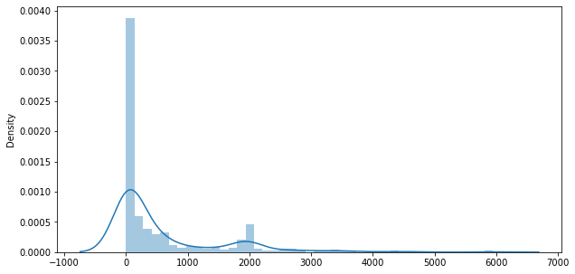

```python
plt.figure(figsize=(10,5))

sns.distplot(basketBallDf[['Score', 'Tournament','PlayedGames','WonGames','DrawnGames','LostGames',
                           'BasketScored', 'BasketGiven','TournamentChampion','Runnerup','TeamLaunch','HighestPositionHeld']])
plt.show()
```

Looks like there is a postive skewness in the plot.

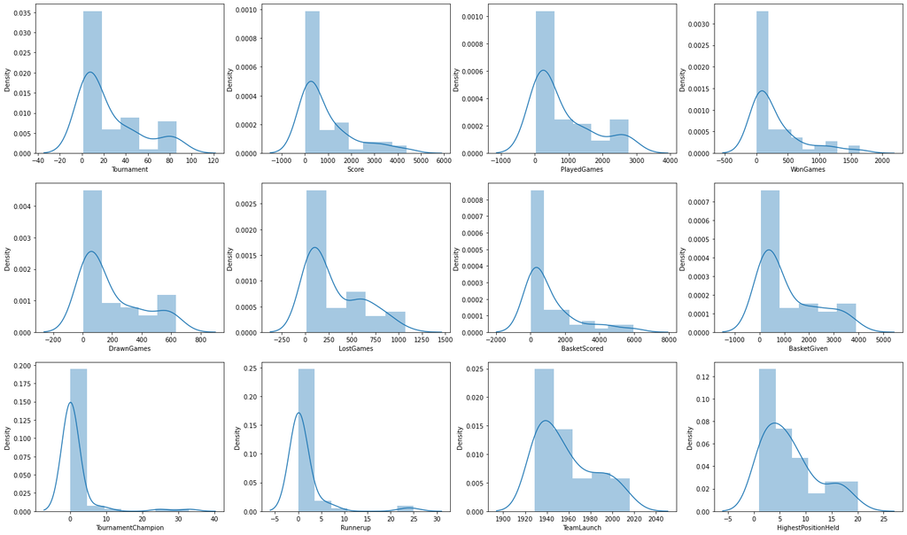

```python
fig, ax = plt.subplots(3,4)

fig.set_figheight(15)
fig.set_figwidth(25)

sns.distplot(basketBallDf['Tournament'], ax = ax[0][0])
sns.distplot(basketBallDf['Score'], ax = ax[0][1])
sns.distplot(basketBallDf['PlayedGames'], ax = ax[0][2])
sns.distplot(basketBallDf['WonGames'], ax = ax[0][3])
sns.distplot(basketBallDf['DrawnGames'], ax = ax[1][0])
sns.distplot(basketBallDf['LostGames'], ax = ax[1][1])
sns.distplot(basketBallDf['BasketScored'], ax = ax[1][2])
sns.distplot(basketBallDf['BasketGiven'], ax = ax[1][3])
sns.distplot(basketBallDf['TournamentChampion'], ax = ax[2][0])
sns.distplot(basketBallDf['Runnerup'], ax = ax[2][1])
sns.distplot(basketBallDf['TeamLaunch'], ax = ax[2][2])
sns.distplot(basketBallDf['HighestPositionHeld'], ax = ax[2][3])

plt.show()
```

Distplot show right skewness in each column attributes

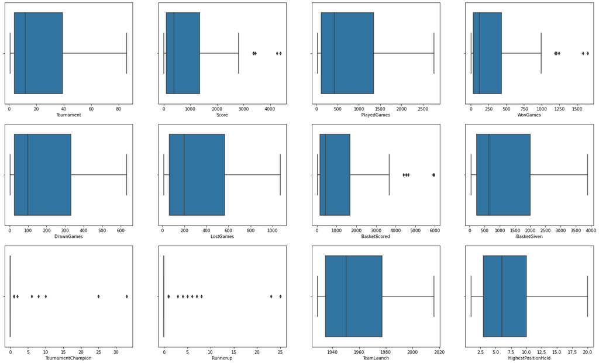

```python
fig, ax = plt.subplots(3,4)

fig.set_figheight(15)
fig.set_figwidth(25)

sns.boxplot(basketBallDf['Tournament'], ax = ax[0][0])
sns.boxplot(basketBallDf['Score'], ax = ax[0][1])
sns.boxplot(basketBallDf['PlayedGames'], ax = ax[0][2])
sns.boxplot(basketBallDf['WonGames'], ax = ax[0][3])
sns.boxplot(basketBallDf['DrawnGames'], ax = ax[1][0])
sns.boxplot(basketBallDf['LostGames'], ax = ax[1][1])
sns.boxplot(basketBallDf['BasketScored'], ax = ax[1][2])
sns.boxplot(basketBallDf['BasketGiven'], ax = ax[1][3])
sns.boxplot(basketBallDf['TournamentChampion'], ax = ax[2][0])
sns.boxplot(basketBallDf['Runnerup'], ax = ax[2][1])
sns.boxplot(basketBallDf['TeamLaunch'], ax = ax[2][2])
sns.boxplot(basketBallDf['HighestPositionHeld'], ax = ax[2][3])

plt.show()
```

Bivairant

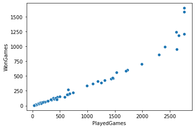

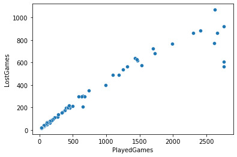

```python
sns.scatterplot(y='WonGames',x ='PlayedGames' ,data=basketBallDf)
plt.show()
sns.scatterplot(y='LostGames',x ='PlayedGames' ,data=basketBallDf)
plt.show()
```

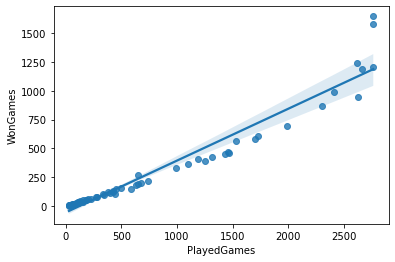

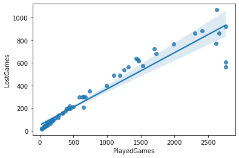

```python
sns.regplot(y='WonGames',x ='PlayedGames' ,data=basketBallDf)
plt.show()
sns.regplot(y='LostGames',x ='PlayedGames' ,data=basketBallDf)
plt.show()
```

There is strong correlation between playedGames, losegames vs total played Games

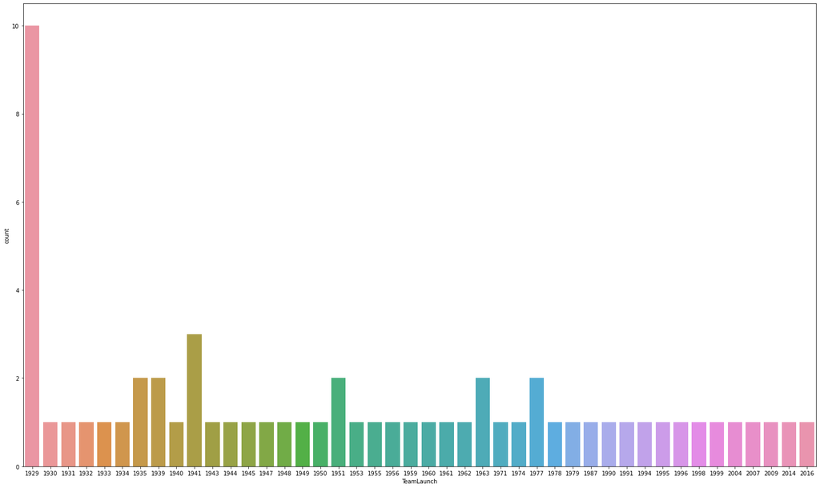

```python
fig, ax = plt.subplots(1)

fig.set_figheight(15)
fig.set_figwidth(25)
sns.countplot(x='TeamLaunch', data=basketBallDf)
```

Maximum number 10 team launched in the year of 1929 After that in 1941 around 3 team has been launched

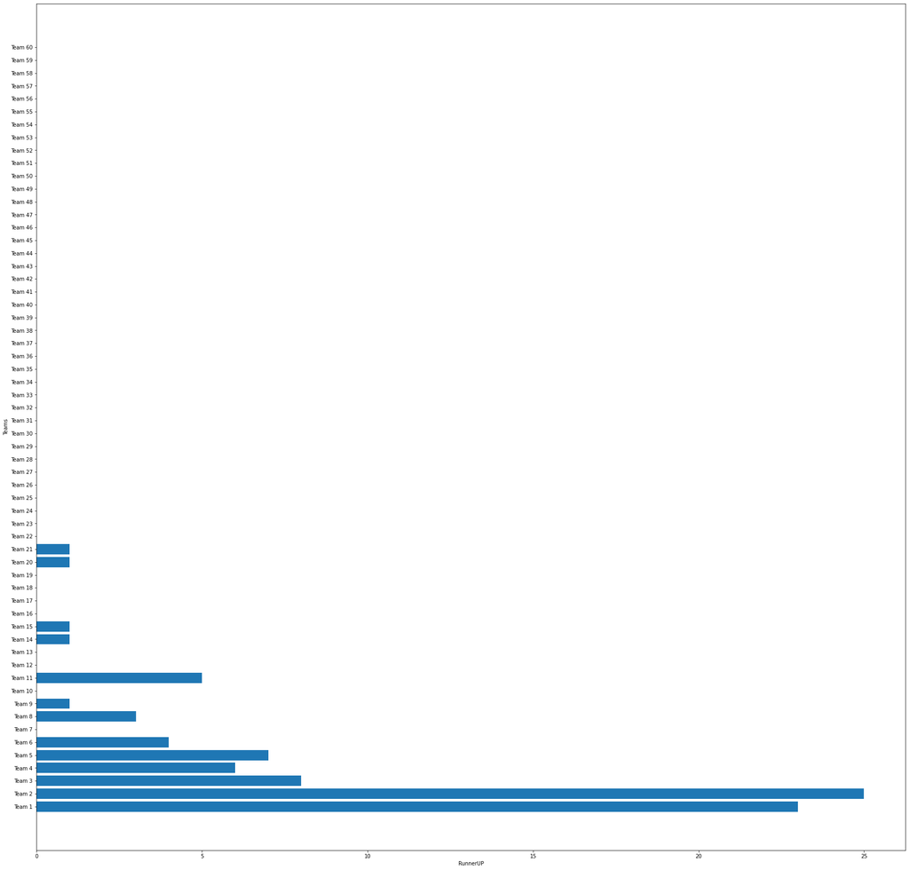

```python
fig, ax = plt.subplots(1)

fig.set_figheight(30)
fig.set_figwidth(30)
ax.barh(basketBallDf['Team'], basketBallDf['Runnerup'])
ax.set_xlabel("RunnerUP")
ax.set_ylabel("Teams")
plt.show()
#sns.barplot(x='Team',y='Runnerup', data=basketBallDf);
```

Team 2 is runner up among teams

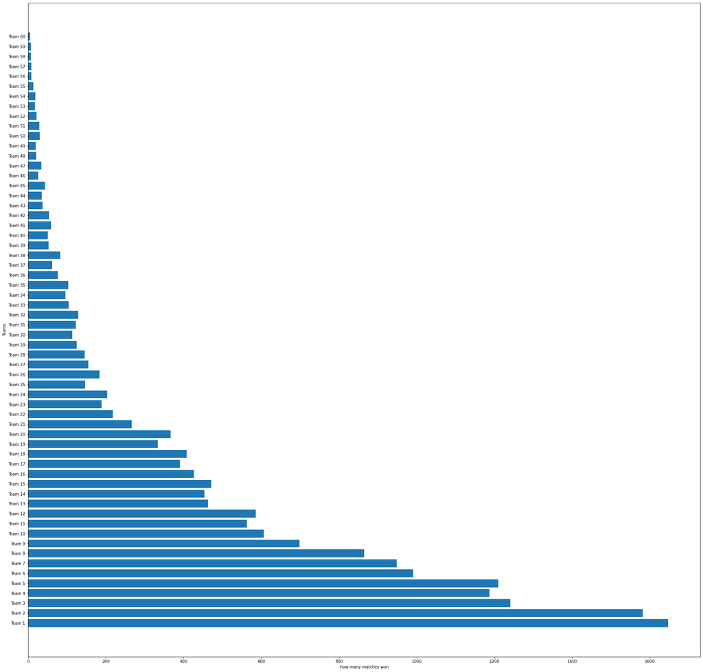

```python
fig, ax = plt.subplots(1)

fig.set_figheight(30)
fig.set_figwidth(30)
ax.barh(basketBallDf['Team'], basketBallDf['WonGames'])
ax.set_xlabel("how many matches won")
ax.set_ylabel("Teams")
plt.show()
#sns.barplot(x='Team',y='Runnerup', data=basketBallDf);
```

Team 1 has won highest games

Is there any correlation between variables ?

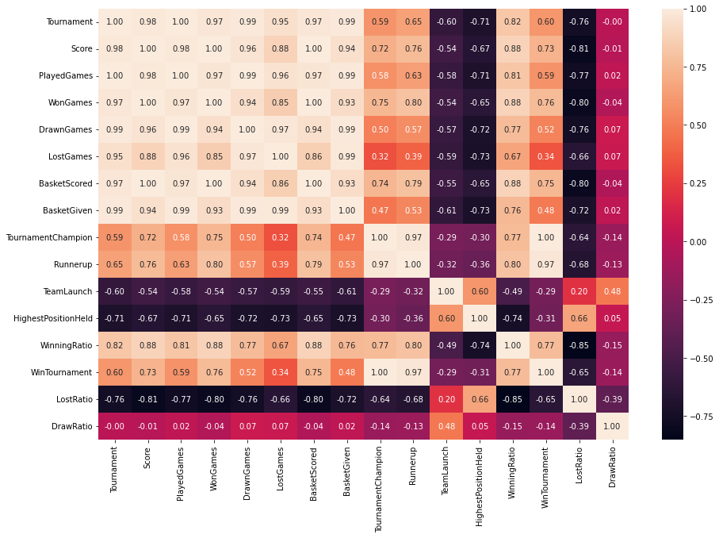

```python
plt.figure(figsize=(15,10))
sns.heatmap(basketBallDf.corr(), annot=True, fmt='0.2f');
```

#### More the tournamenet play, more the chance of BasketScored and BasketGiven

#### Strong correlation between WonGames and BasketScored

#### When any team lost, we will lose the BasketGiven

#### Tournamentchampion depends more on Won Games.If team wins then more chance to win tournament.

#### More the game win , more the score, more the basketscored

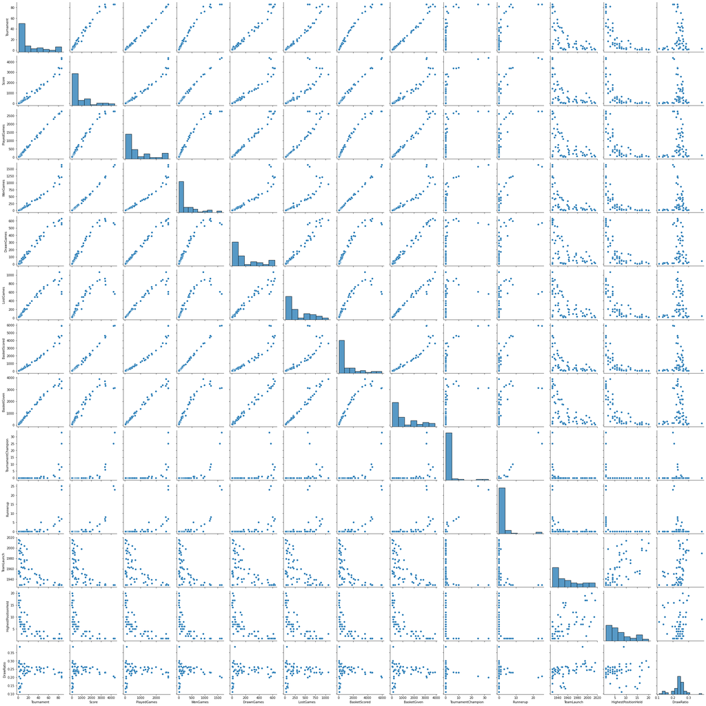

```python
baskBalDf2= basketBallDf.drop(['Team', 'WinningRatio', 'WinTournament','LostRatio'],axis=1)
sns.pairplot(baskBalDf2);
```

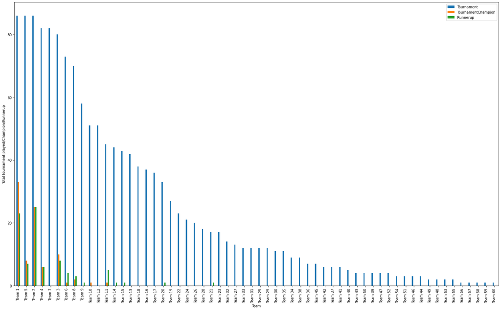

```python
sort_basketBallDf = basketBallDf.sort_values(by='Tournament', ascending=False);
sort_basketBallDf.plot(x="Team", y=["Tournament", "TournamentChampion", "Runnerup"], kind="bar",figsize=(25,15), ylabel='Total tournament played/Champion/Runnerup');
plt.show()
```

#### Top 5 teams are Team 1, Team 2, team 3, team 4, team 5 which have higher chance of winning tournament

#### Team 1,2,5 played same tournament, but team1 won tournamentchamption most of the time

### team 9, 14, 15, 20 , team 21 are only runner up.

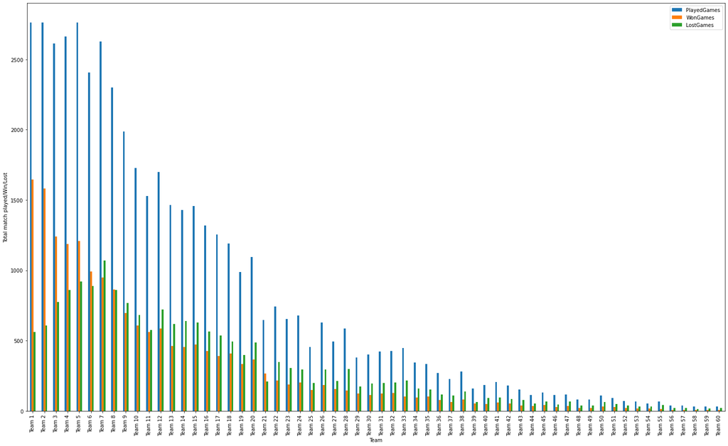

```python
basketBallDf.plot(x="Team", y=["PlayedGames", "WonGames", "LostGames"], kind="bar",figsize=(25,15), ylabel='Total match played/Win/Lost');
plt.show()
```

```python
basketBallDf[['Team','PlayedGames', 'WinningRatio', 'WinTournament','LostRatio']].sort_values(by=['PlayedGames','WinningRatio'], ascending=False).head(10)
```

|  | Team | PlayedGames | WinningRatio | WinTournament | LostRatio |
| --- | --- | --- | --- | --- | --- |
| 0 | Team 1 | 2762 | 0.596307 | 0.383721 | 0.203838 |
| 1 | Team 2 | 2762 | 0.572411 | 0.290698 | 0.220130 |
| 4 | Team 5 | 2762 | 0.437726 | 0.093023 | 0.333092 |
| 3 | Team 4 | 2664 | 0.445571 | 0.073171 | 0.323198 |
| 6 | Team 7 | 2626 | 0.361005 | 0.000000 | 0.407464 |
| 2 | Team 3 | 2614 | 0.474751 | 0.125000 | 0.296480 |
| 5 | Team 6 | 2408 | 0.411130 | 0.013699 | 0.368355 |
| 7 | Team 8 | 2302 | 0.375326 | 0.028571 | 0.374023 |
| 8 | Team 9 | 1986 | 0.351460 | 0.000000 | 0.385700 |
| 9 | Team 10 | 1728 | 0.350694 | 0.019608 | 0.394676 |

### Team1 has highest winning ratio

### Team2 is the runner up and have the maximum chance if team1 is not win.

### Team 1,2,5 played same games, but team1 won maximum matches. Team1 > Team2> Team5

```python
## PANDAS Profiling for BasketBall
```

```python
from pandas_profiling import ProfileReport
profile = ProfileReport(basketBallDf)
profile.to_file("BasketBall_Profiling.html")
```

# Improvement

#### 4 Variety: More information should be provided. For example for each year, how many match team wins. This may be possible that older team which was good earlier, may not be good now. Team won the maximum match earlier and now he is not performing well.

#### 5) Velocity:Our data set is small , it has out liers and missing information . With these , Eventually it effects the reliability of its results.

#### 6) Veracity: Missing data and outliers affect the end result. The data should be free from missing data as well as outliers.

#### 7) Missing information.

#### 8) Many outlier are present in the dataset.

#### 9) Volume: DataSet has only 61 records. Data is not enough

#### 10) If we have attribute which contain range of year. This attribute should tell us how much match team won in the range period. This would be useful. If older team won each and every match in the previous period because of its players and now team is not performing from the last X years. There is no way to invest money in that team.

# Part C

# Read the CSV file.

```python
df = pd.read_csv('CompanyX_EU.csv')
df.head()
```

|  | Startup | Product | Funding | Event | Result | OperatingState |
| --- | --- | --- | --- | --- | --- | --- |
| 0 | 2600Hz | 2600hz.com | NaN | Disrupt SF 2013 | Contestant | Operating |
| 1 | 3DLT | 3dlt.com | $630K | Disrupt NYC 2013 | Contestant | Closed |
| 2 | 3DPrinterOS | 3dprinteros.com | NaN | Disrupt SF 2016 | Contestant | Operating |
| 3 | 3Dprintler | 3dprintler.com | $1M | Disrupt NY 2016 | Audience choice | Operating |
| 4 | 42 Technologies | 42technologies.com | NaN | Disrupt NYC 2013 | Contestant | Operating |

# Data Exploration:

# Check the datatypes of each attribute.

```python
df.dtypes
```

```
Startup           object
Product           object
Funding           object
Event             object
Result            object
OperatingState    object
dtype: object
```

# Check for null values in the attributes.

```python
df.isna().sum()
```

```
Startup             0
Product             6
Funding           214
Event               0
Result              0
OperatingState      0
dtype: int64
```

# Data preprocessing & visualisation:

# Drop the null values.

```python
df.dropna(inplace=True)
```

# Convert the ‘Funding’ features to a numerical value.

```python
df.loc[:,'Funds_in_million'] = df['Funding'].apply(lambda x: float(x[1:-1])/1000 if x[-1] == 'K' else (float(x[1:-1])*1000 if x[-1] == 'B' else float(x[1:-1])))
```

# Plot box plot for funds in million

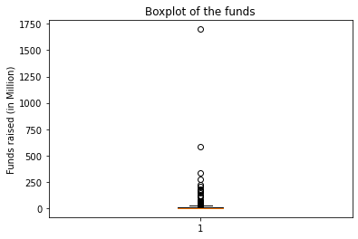

```python
plot=plt.boxplot(x='Funds_in_million', data=df)
plt.title('Boxplot of the funds')
plt.ylabel("Funds raised (in Million)")
plt.show()
```

# Check the number of outliers greater than the upper fence

```python
Q1= df['Funds_in_million'].quantile(0.25);
Q3= df['Funds_in_million'].quantile(0.75);
IQR = Q3-Q1;
upper_fence= Q3+(1.5*IQR)
print(f'Number of outliers: {len(df[df.Funds_in_million > upper_fence])}')
#df[df.Funds_in_million > upper_fence]
```

```
Number of outliers: 60
```

# E Check frequency of the OperatingState features classes.

```python
df['OperatingState'].value_counts()
```

```
Operating    319
Acquired      66
Closed        57
Ipo            4
Name: OperatingState, dtype: int64
```

# 4 Statistical Analysis:

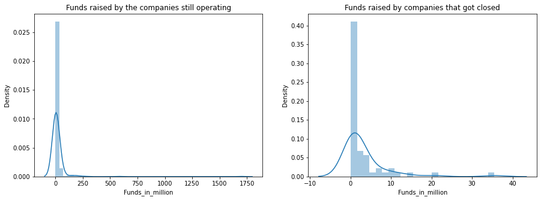

```python
fig, ax = plt.subplots(1, 2)

fig.set_figheight(5)
fig.set_figwidth(15)

sns.distplot(df.loc[df.OperatingState == 'Operating', 'Funds_in_million'], ax = ax[0])
sns.distplot(df.loc[df.OperatingState =='Closed', 'Funds_in_million'], ax = ax[1])

ax[0].set_title('Funds raised by the companies still operating')
ax[1].set_title('Funds raised by companies that got closed')
plt.show()
```

#### To prove if there is a significant difference or not we will have to perform a hypothesis test

# B. Write the null hypothesis and alternative hypothesis.

#### H0 : There is no difference in their mean of funds raised by companies still operating and funds raised by companies that got closed

#### H1: There is a difference in their mean raised by companies still operating and funds raised by companies that got closed

```python
from statsmodels.stats.weightstats import ztest

sample1 =df.loc[df.OperatingState=='Operating','Funds_in_million']
sample2 = df.loc[df.OperatingState=='Closed', 'Funds_in_million']
zscore, p_value = ztest(sample1, sample2)

alpha = 0.05   # Let's consider a significance level of 5%
if p_value < 0.05:
    print(f'Since the p-value {round(p_value,3)} is less than {alpha}  the difference is significant. Hence Rejecting H0 hypothesis')
else:
    print(f'P-value {round(p_value,3)} > alpha {alpha} and  the difference is not significant. Hence Failed to Reject null hypothesis')
```

```
P-value 0.255 > alpha 0.05 and  the difference is not significant. Hence Failed to Reject null hypothesis
```

# Make a copy of the original data frame.

```python
df1 = df.copy(deep=True)
df1.head()
```

|  | Startup | Product | Funding | Event | Result | OperatingState | Funds_in_million |
| --- | --- | --- | --- | --- | --- | --- | --- |
| 1 | 3DLT | 3dlt.com | $630K | Disrupt NYC 2013 | Contestant | Closed | 0.63 |
| 3 | 3Dprintler | 3dprintler.com | $1M | Disrupt NY 2016 | Audience choice | Operating | 1.00 |
| 5 | 5to1 | 5to1.com | $19.3M | TC50 2009 | Contestant | Acquired | 19.30 |
| 6 | 8 Securities | 8securities.com | $29M | Disrupt Beijing 2011 | Finalist | Operating | 29.00 |
| 10 | AdhereTech | adheretech.com | $1.8M | Hardware Battlefield 2014 | Contestant | Operating | 1.80 |

# Check frequency distribution of Result variables

```python
df1.Result.value_counts()
```

```
Contestant         312
Finalist            65
Audience choice     25
Winner              25
Runner up           19
Name: Result, dtype: int64
```

# Calculate percentage of winners that are still operating and percentage of contestants that are still operating

```python
winners = df1.Result.value_counts()['Winner']
contestants = df1.Result.value_counts()['Contestant']
```

```python
contestants_operating = df1.OperatingState[df1.Result == 'Contestant'].value_counts().loc['Operating']
winners_operating = df1.OperatingState[df1.Result == 'Winner'].value_counts().loc['Operating']
```

```python
print("percentage of winners that are still operating is",(winners_operating/winners)*100)
print("percentage of contestants that are still operating is", (contestants_operating/contestants)*100)
```

```
percentage of winners that are still operating is 72.0
percentage of contestants that are still operating is 68.58974358974359
```

# There is some difference between the proportion operational companies in the two categories, but let's see if the differnce is significant

There are two ways we can check if the difference is significant Z-test for proportions Chi-square test We shall perform z-test in this case, however, do experiment with Chi-square test and observe if the p-value from both tests gives the same conclusion or not

Null hyputhesis (Ho): The proportion of companies that are operating is the same in both categories - winners and contestants

Alternative hypothesis (Ha): The proportion of companies that are operating is significantly different from each other, among the two categories

# Test for significance and conclusion

```python
from statsmodels.stats.proportion import proportions_ztest

test_statistic, p_value = proportions_ztest([contestants_operating, winners_operating], [contestants, winners])

if p_value <= alpha:
    print(f'Since the p-value, {round(p_value, 3)} < {alpha} (alpha) the difference is significant and we reject the Null hypothesis')
else:
    print(f'''\t Since the p-value, {round(p_value,3)} > {alpha} (alpha) the difference is not significant and,
    \t we fail to reject the Null hypothesis''')
```

```
	 Since the p-value, 0.723 > 0.05 (alpha) the difference is not significant and,
    	 we fail to reject the Null hypothesis
```

# Select only the Event that has ‘disrupt’ keyword from 2013 onwards.

```python
events = df1[df1.Event.apply(lambda x: 'Disrupt' in x and int(x[-4:]) > 2012)].Event  # all the events of relevance
events
```

```
1         Disrupt NYC 2013
3          Disrupt NY 2016
13         Disrupt SF 2015
14     Disrupt London 2016
16         Disrupt SF 2015
              ...
641       Disrupt NYC 2013
642        Disrupt SF 2014
646    Disrupt London 2015
656       Disrupt NYC 2013
660        Disrupt SF 2013
Name: Event, Length: 193, dtype: object
```